# Point Clustering in R

Jeremy R. Porter

Spring 2019

#### Using the data we extracted from the NOAA SLOSH models, we are going to read the data into R and test to see if homes are risk of storm surge are clustered in space. We’d expect the higher probability storms (c1/c2) to produce strong clusters given coastal proximity, but as we increase in storm classification strength we are not sure how new homes are distributed across the ocean city, md.

#### First, let’s set our working directory for any files we may write from R….

```r
knitr::opts_chunk$set(
    echo = TRUE,
    message = TRUE,
    warning = TRUE
)
setwd("C:/Users/Jeremy/Desktop/Spring2019/ADV_GIS/Week5")
```

#### Next, let’s require the `RPostgres` pacakage (Note: for any package not already installed in your local environment, you should first `install.packages("[Package Name]")`)

```r
require(RPostgres)
```

#### Using the `RPostgres` package, we are going to setup a connection with the postGIS database we have setup on our local machines. The setup process includes the creation of a new R object containing all of the setup information, `conn`. To create the `conn` object, we will use the `dcConnect` funtion to connect to `Postgres()` in the `RPostgres` package `(RPostgres::Postgres())`. Our database name is `advanced_gis`, the host is `localhost`, the port is `5432`, user is `postgres`, and my password is `jeremy`. Finally, I set the `digits = 10` to truncate any really long real numbers that are produced as part of the data transfer from Postgres to R.

```r
conn <- dbConnect(RPostgres::Postgres(), dbname = 'advanced_gis',
                  host = 'localhost', # i.e. 'your computer'
                  port = 5432, # or any other port specified by your DBA
                  user = 'postgres',
                  password = 'jeremy')


options(digits = 10)
```

#### The next chuck of code is creating the R object `oc_prop_SLOSH` and `oc_sale_data` using the `dbFetch` function which sends and `SQL` query to the Postgis database via the `dbSendQuery` function and separate `SQL` queries. In this lab we are interested in the hurricane classification data from `oc_prop_SLOSH` `("SELECT c1_high, c2_high, c3_high, c4_high FROM lab5.oc_prop_slosh_samp")` and all of the data from `oc_sale_data` `("SELECT * FROM lab4.prop_val_sample_oc")`. Once both data sets are read into R, let’s bind them together using the `cbind` function so that the hurricane information is now attached to the sale data.

```r
oc_prop_SLOSH <- dbFetch(dbSendQuery(conn, "SELECT c1_high, c2_high, c3_high, c4_high
                                     FROM lab5.oc_prop_slosh_samp"))

oc_sale_data <- dbFetch(dbSendQuery(conn, "SELECT *
                                    FROM lab4.prop_val_sample_oc"))

data <- cbind(oc_sale_data,oc_prop_SLOSH)
```

#### Next, I’m going to explore the data using the `head` and `summary` functions. It looks like the `x` and `y` variables are character so the first thing I want to do is convert them to real numbers using the `as.numeric()` function. Also, I want to convert all hurricane inundation values of `99.9` to `0` using the `ifelse()` function. This function as `3` arguments: the first is the condition that needs to be met, the second is the recoded value if the condition is met, the thrid is the recoded value if the condition is not met. Here we are saying that if the value is equal to `99.9`, recode it to `0`. If the value is not `99.9` keep the existing value.

```r
head(data, n=10)
```

```
##    id         pr_sq_ft         fsid saleyear                 x
## 1   1 436.451897616946 240472086092     2005  -75.138926115869
## 2   2 436.451897616946 240472086092     2005  -75.138926115869
## 3   3 225.694444444444 240472086093     2006 -75.1659203893891
## 4   4 124.710648148148 240472086093     2011 -75.1659203893891
## 5   5 124.710648148148 240472086093     2011 -75.1659203893891
## 6   6 211.236933797909 240472086097     2006 -75.1628691231124
## 7   7 211.236933797909 240472086097     2006 -75.1628691231124
## 8   8 171.102661596958 240472086099     2018 -75.1774784550946
## 9   9 198.669201520913 240472086099     2006 -75.1774784550946
## 10 10 198.669201520913 240472086099     2007 -75.1774784550946
##                   y        samp_pr05
## 1  38.3920173234802 336.576542179343
## 2  38.3920173234802 336.576542179343
## 3  38.3828555299029 185.907421393261
```

[output cut: 29 more lines]

```r
summary(data)
```

```
##        id            pr_sq_ft             fsid
##  Min.   :   1.00   Length:4086        Length:4086
##  1st Qu.:1022.25   Class :character   Class :character
##  Median :2043.50   Mode  :character   Mode  :character
##  Mean   :2043.50
##  3rd Qu.:3064.75
##  Max.   :4086.00
##    saleyear              x                  y
##  Length:4086        Length:4086        Length:4086
##  Class :character   Class :character   Class :character
##  Mode  :character   Mode  :character   Mode  :character
##
##
##
##   samp_pr05             geom                c1_high
##  Length:4086        Length:4086          Min.   : 0.00000
##  Class :character   Class :pq_geometry   1st Qu.: 4.20000
##  Mode  :character   Mode  :character     Median :99.90000
##                                          Mean   :68.88111
##                                          3rd Qu.:99.90000
##                                          Max.   :99.90000
##     c2_high            c3_high            c4_high
##  Min.   : 0.00000   Min.   : 0.20000   Min.   : 0.00000
##  1st Qu.: 3.80000   1st Qu.: 5.90000   1st Qu.:10.40000
##  Median : 9.40000   Median :10.70000   Median :15.20000
##  Mean   :47.52472   Mean   :23.21038   Mean   :25.03245
##  3rd Qu.:99.90000   3rd Qu.:14.60000   3rd Qu.:18.60000
##  Max.   :99.90000   Max.   :99.90000   Max.   :99.90000
```

```r
data$x <- as.numeric(data$x)
data$y <- as.numeric(data$y)

data$c1_high <- ifelse(data$c1_high==99.9, 0, data$c1_high)
data$c2_high <- ifelse(data$c2_high==99.9, 0, data$c2_high)
data$c3_high <- ifelse(data$c3_high==99.9, 0, data$c3_high)
data$c4_high <- ifelse(data$c4_high==99.9, 0, data$c4_high)

head(data, n=10)
```

```
##    id         pr_sq_ft         fsid saleyear            x           y
## 1   1 436.451897616946 240472086092     2005 -75.13892612 38.39201732
## 2   2 436.451897616946 240472086092     2005 -75.13892612 38.39201732
## 3   3 225.694444444444 240472086093     2006 -75.16592039 38.38285553
## 4   4 124.710648148148 240472086093     2011 -75.16592039 38.38285553
## 5   5 124.710648148148 240472086093     2011 -75.16592039 38.38285553
## 6   6 211.236933797909 240472086097     2006 -75.16286912 38.36604107
## 7   7 211.236933797909 240472086097     2006 -75.16286912 38.36604107
## 8   8 171.102661596958 240472086099     2018 -75.17747846 38.39534681
## 9   9 198.669201520913 240472086099     2006 -75.17747846 38.39534681
## 10 10 198.669201520913 240472086099     2007 -75.17747846 38.39534681
##           samp_pr05                                               geom
## 1  336.576542179343 0101000020AD100000EE0D5D2AE4C852C00DE8A79F2D324340
## 2  336.576542179343 0101000020AD100000EE0D5D2AE4C852C00DE8A79F2D324340
## 3  185.907421393261 0101000020AD1000009C8A8D709ECA52C04A03F66801314340
```

[output cut: 18 more lines]

```r
summary(data)
```

```
##        id            pr_sq_ft             fsid
##  Min.   :   1.00   Length:4086        Length:4086
##  1st Qu.:1022.25   Class :character   Class :character
##  Median :2043.50   Mode  :character   Mode  :character
##  Mean   :2043.50
##  3rd Qu.:3064.75
##  Max.   :4086.00
##    saleyear               x                   y
##  Length:4086        Min.   :-75.29906   Min.   :38.21253
##  Class :character   1st Qu.:-75.16946   1st Qu.:38.33430
##  Mode  :character   Median :-75.15318   Median :38.37130
##                     Mean   :-75.15863   Mean   :38.36193
##                     3rd Qu.:-75.13754   3rd Qu.:38.38880
##                     Max.   :-75.06681   Max.   :38.45087
##   samp_pr05             geom                c1_high
##  Length:4086        Length:4086          Min.   :0.00000
##  Class :character   Class :pq_geometry   1st Qu.:0.00000
##  Mode  :character   Mode  :character     Median :0.00000
##                                          Mean   :1.03419
##                                          3rd Qu.:1.60000
##                                          Max.   :6.90000
##     c2_high             c3_high             c4_high
##  Min.   : 0.000000   Min.   : 0.000000   Min.   : 0.00000
##  1st Qu.: 0.000000   1st Qu.: 3.800000   1st Qu.: 8.70000
##  Median : 0.500000   Median : 9.600000   Median :13.90000
##  Mean   : 2.244542   Mean   : 7.905091   Mean   :11.82981
##  3rd Qu.: 4.100000   3rd Qu.:13.100000   3rd Qu.:17.60000
##  Max.   :12.000000   Max.   :17.500000   Max.   :22.50000
```

#### Now that the data are clean and read into R, let’s load the packages necessary for the cluster anlaysis. I’m loading `rgdal` to read a boundary file I gave you with the lab materials `maptools` will be used to convert the `x` and `y` variables to spatial coordinates, and the `spatstat` package is used to identify clusters in the physical locations of the point data.

```r
require(rgdal)
require(maptools)
require(spatstat)
```

#### To test for spatial clusters, I need to set up a bounding window for the data which I do by reading in a bounding box I created through the `readOGR` function. Next, I convert that bounding box to a window by specifying the `border2` object (bounding box I just read in) `as` an observation window `(owin)`. Once the observation window is set, I need to convert the `data.frame` to a `SpatialPointsDataFrame` by converting `x` and `y` to spatial `coordinates` and projecting the new `data` object to a `CRS`.

```r
border2<-readOGR(dsn="C:/Users/Jeremy/Desktop/spring2019/Adv_GIS/week5", layer="bounds")
boundry<-as(border2,"owin")
coordinates(data)=~x+y
proj4string(data)=CRS("+init=epsg:4269")
```

#### When I explore the new `SpatialPointsDataFrame` using the `head` command, I can see the data from the original dataset. Today, we want to identify the degree to which homes at risk of flooding from a specific classification of hurricane are clusterd in space. For this analysis, I am going to separate homes based on first hurricane experienced. So while a home that experiences inundation from a `C1` would also experience inundation from a `C4`, I’m only going to include them in the `C1` group. To create the “First Risk” groupings, I have used the `subset` function and applied it to the original `data` object with conditions to be met for the new subsets. After pulling the new subsets of data, I plot each of them.

```r
head(data)
```

```
##                   coordinates id         pr_sq_ft         fsid saleyear
## 1 (-75.13892612, 38.39201732)  1 436.451897616946 240472086092     2005
## 2 (-75.13892612, 38.39201732)  2 436.451897616946 240472086092     2005
## 3 (-75.16592039, 38.38285553)  3 225.694444444444 240472086093     2006
## 4 (-75.16592039, 38.38285553)  4 124.710648148148 240472086093     2011
## 5 (-75.16592039, 38.38285553)  5 124.710648148148 240472086093     2011
## 6 (-75.16286912, 38.36604107)  6 211.236933797909 240472086097     2006
##          samp_pr05                                               geom
## 1 336.576542179343 0101000020AD100000EE0D5D2AE4C852C00DE8A79F2D324340
## 2 336.576542179343 0101000020AD100000EE0D5D2AE4C852C00DE8A79F2D324340
## 3 185.907421393261 0101000020AD1000009C8A8D709ECA52C04A03F66801314340
## 4 185.907421393261 0101000020AD1000009C8A8D709ECA52C04A03F66801314340
## 5 185.907421393261 0101000020AD1000009C8A8D709ECA52C04A03F66801314340
## 6 180.502237734179 0101000020AD100000F1529D726CCA52C050EC0E6FDA2E4340
##   c1_high c2_high c3_high c4_high
## 1     1.4     3.7    13.8    18.0
## 2     1.4     3.7    13.8    18.0
## 3     0.0     0.0     4.6     9.1
## 4     0.0     0.0     4.6     9.1
## 5     0.0     0.0     4.6     9.1
## 6     0.0     0.0     4.2     8.7
```

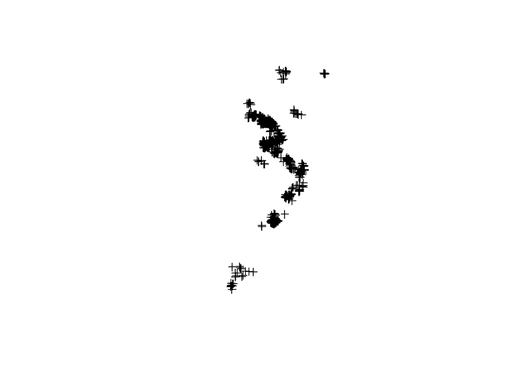

```r
data_c1 <- subset(data, c1_high > 0)
data_c2 <- subset(data, c2_high > 0 & c1_high ==0)
data_c3 <- subset(data, c3_high > 0 & c2_high ==0)
data_c4 <- subset(data, c4_high > 0 & c3_high ==0)

plot(data_c1)
```

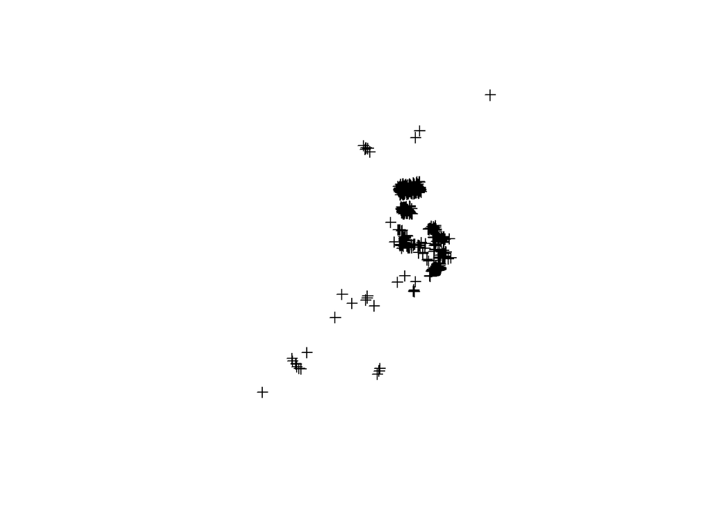

```r
plot(data_c2)
```

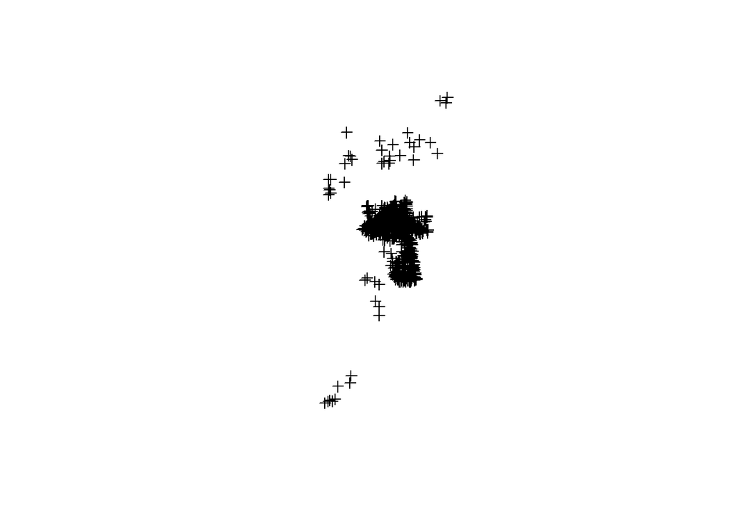

```r
plot(data_c3)
```

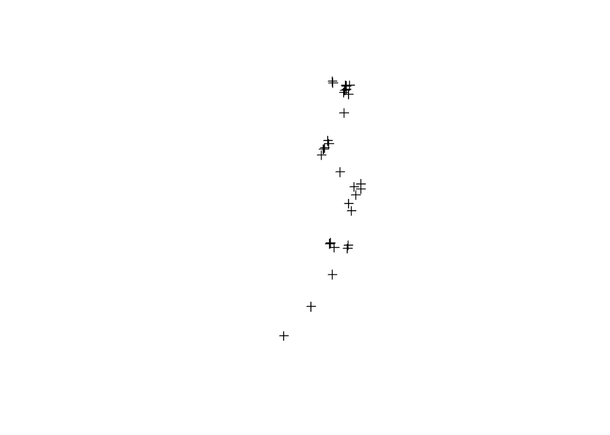

```r
plot(data_c4)
```

```r
MD_border1<-ppp(data_c1$x,data_c1$y,window=boundry)
L_c1<-envelope(MD_border1, Lest, nsim=10, rank=2, global=T)
```

```
## Generating 10 simulations of CSR  ...
## 1, 2, 3, 4, 5, 6, 7, 8, 9,  10.
##
## Done.
```

```r
MD_border2<-ppp(data_c2$x,data_c2$y,window=boundry)
L_c2<-envelope(MD_border2, Lest, nsim=10, rank=2, global=T)
```

```
## Generating 10 simulations of CSR  ...
## 1, 2, 3, 4, 5, 6, 7, 8, 9,  10.
##
## Done.
```

```r
MD_border3<-ppp(data_c3$x,data_c3$y,window=boundry)
L_c3<-envelope(MD_border3, Lest, nsim=10, rank=2, global=T)
```

```
## Generating 10 simulations of CSR  ...
## 1, 2, 3, 4, 5, 6, 7, 8, 9,  10.
##
## Done.
```

```r
MD_border4<-ppp(data_c4$x,data_c4$y,window=boundry)
L_c4<-envelope(MD_border4, Lest, nsim=10, rank=2, global=T)
```

```
## Generating 10 simulations of CSR  ...
## 1, 2, 3, 4, 5, 6, 7, 8, 9,  10.
##
## Done.
```

#### Let’s plot our new `MD_border` objects to see the points within the observation window. They clearly look clustered.

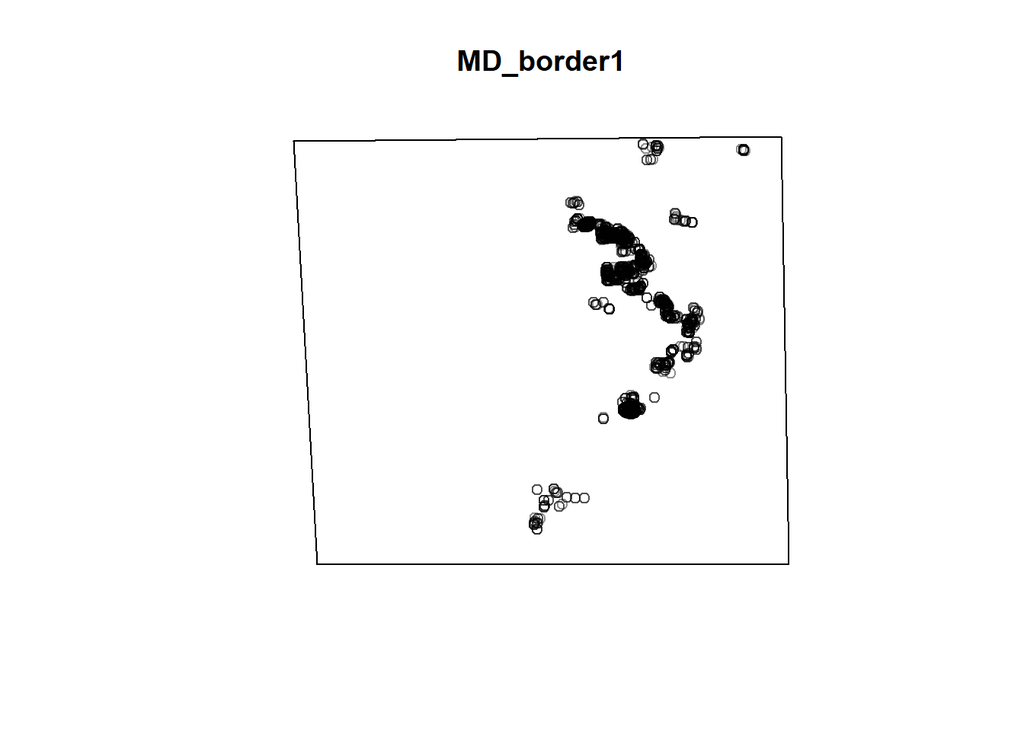

```r
plot(MD_border1)
```

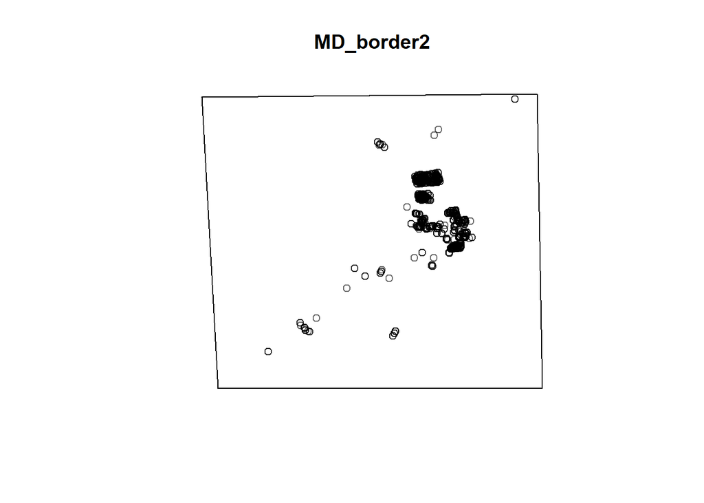

```r
plot(MD_border2)
```

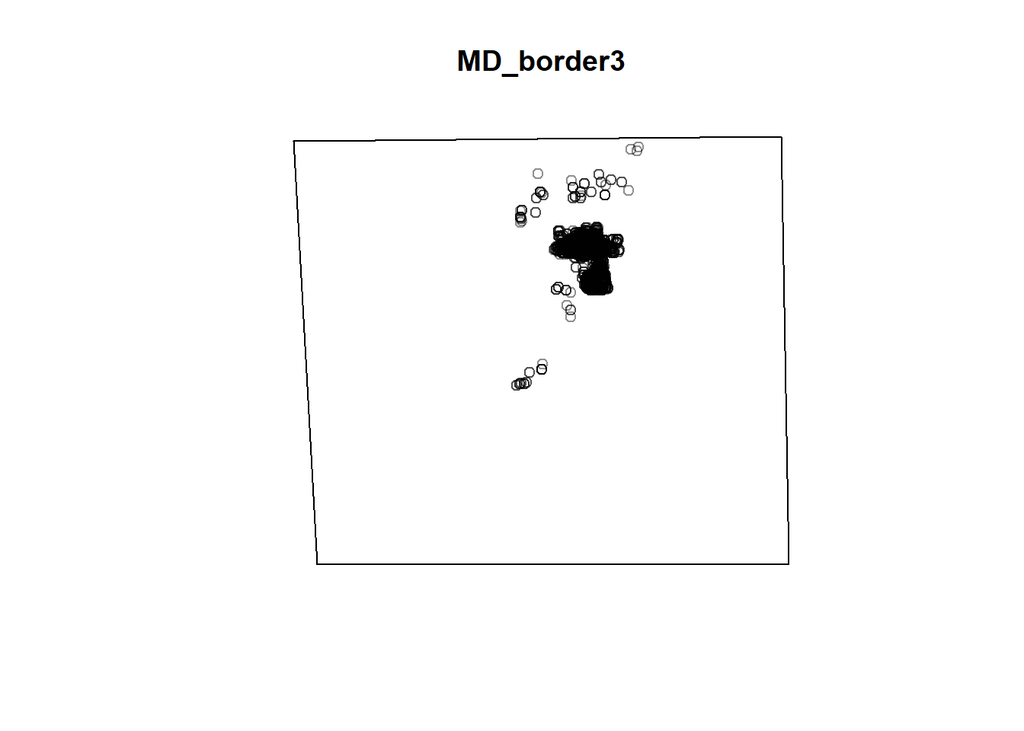

```r
plot(MD_border3)
```

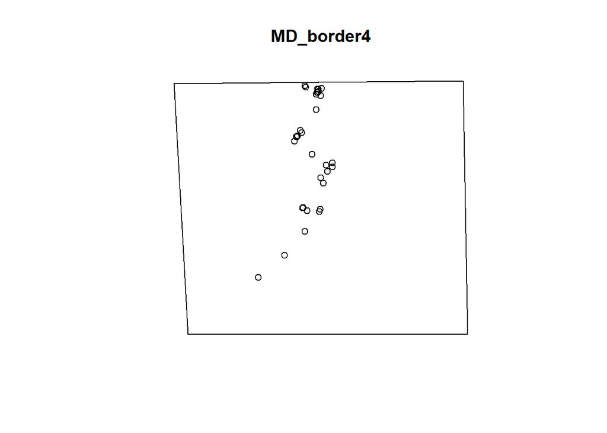

```r
plot(MD_border4)
```

#### After the clustering test is implemented, we can plot the results to better understand the physical distribution of homes at risk by `First Risk`. To plot the data I am going the create a 2x2 plot matrix using the `par(mfrow=c(2,2))` command. Next I am going to plot each clustering test one at a time and add an x-axis label of `"Distance"` and y-axis lable of `"Density Function"`… along with some text to title the plot. Export the plot to a PDF and view it in your PDF viewer to see the proper image.

```r
dev.off()
```

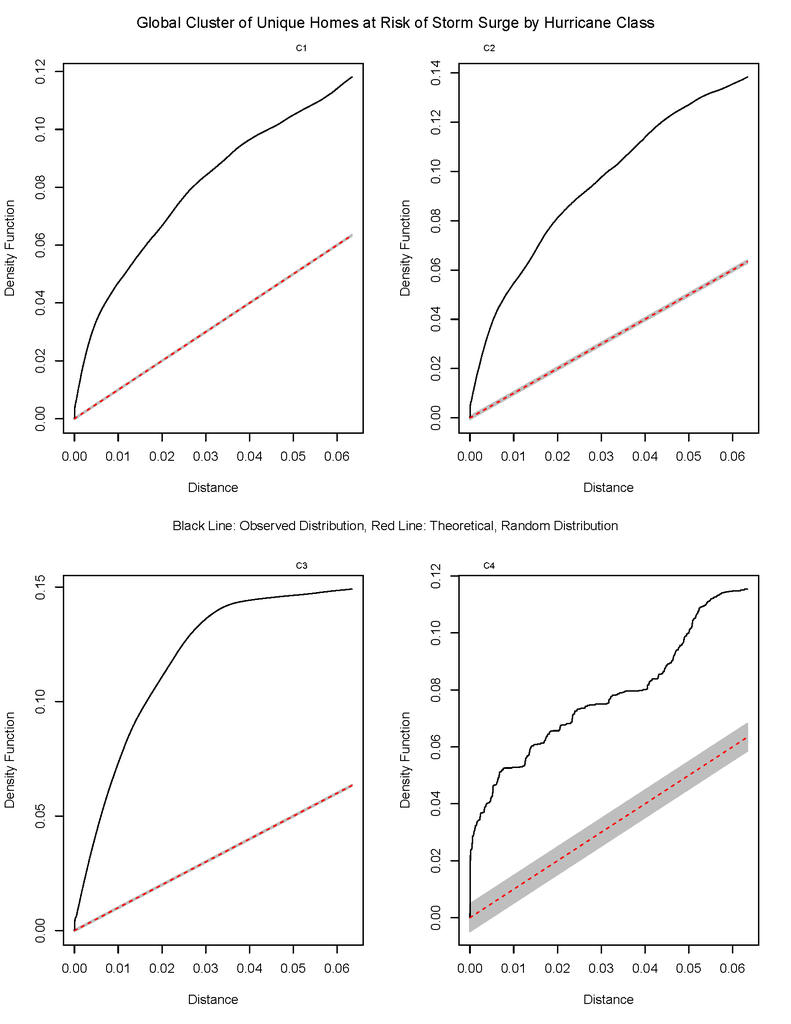

```r
par(mfrow=c(2,2))

plot(L_c1, cex=0.03, main=NULL, ylab="Density Function",
     xlab="Distance", legend=F)
plot(L_c2, cex=0.03, main=NULL, ylab="Density Function",
     xlab="Distance", legend=F)
plot(L_c3, cex=0.03, main=NULL, ylab="Density Function",
     xlab="Distance", legend=F)
plot(L_c4, cex=0.03, main=NULL, ylab="Density Function",
     xlab="Distance", legend=F)
mtext("Global Cluster of Unique Homes at Risk of Storm Surge by Hurricane Class", side =3,
      line = -2, outer = TRUE, cex = 1.0)
mtext("Black Line: Observed Distribution, Red Line: Theoretical, Random Distribution",
      side =3, line = -34.5, outer = TRUE, cex = 0.85)
mtext("C1                                                                      C2",
      side =3, line = -3.5, outer = TRUE, cex = 0.6)
mtext("C3                                                                      C4",
      side =3, line = -37, outer = TRUE, cex = 0.6)
```

#### For you lab deliverable #5 sumbit 4 panel map of cluserting results based on year of home sales. The four groups should be subsets of `saleyear =` `2005`,`2009`,`2013`,`2017`. The subsets should represent only homes sold during that year based on the `saleyear` variable. (HINT: you already have the data in the `data` object in your current R environment.)